# Zambia’s public money, checked by the Auditor General

What the audit reports for 2021 to 2025 actually say, in plain terms

Published

November 11, 2026

> **What this is.** Every year, Zambia’s Auditor General checks how the government collected and spent public money, and publishes a report. This page sums up five of those reports, for the years 2021 to 2025, in plain language. Every figure comes straight from the reports, and the page number is on record.

> **One thing to keep in mind.** An audit “finding” is a question the auditors could not close, not a proven crime. It means the records did not fully add up, or an explanation was still owed when the report was written. So read these as “money the government could not fully account for,” not “money that was stolen.”

# The short version

|  | Amount / figure |
| --- | --- |
| Government planned to spend (2025) | K250.68bn |
| Government actually spent (2025) | K216.30bn |
| Left unspent against the plan (2025) | K34.38bn |
| Surplus: collected minus spent (2025) | K2.11bn |
| Open audit questions in 2025 | 27 |
| Open audit questions in 2022 | 40 |

Over these five years:

- The government is spending a **bigger share of its budget** than before: 76 out of every 100 Kwacha budgeted in 2022, rising to about 86 in 2025.
- Its **surplus has shrunk**, from about K30 billion in 2022 to about K2 billion in 2025. It now collects and spends much closer to the line.
- The **number of unresolved audit questions has fallen**, from 40 in 2022 to 27 in 2025.
- But the **same ministries keep coming up** year after year, and the reports still list large sums not collected, not delivered, or not properly supported, including specific contracts (below).

# How government money moved

Each report compares what the government **planned** to spend (the final budget) with what it **actually** spent.

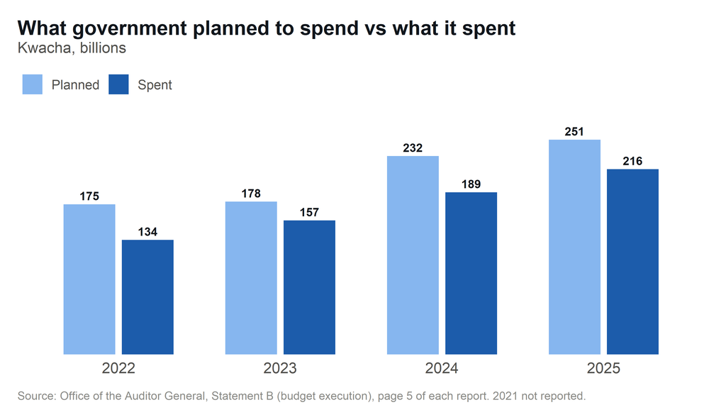

In 2025 the government planned to spend about **K251 billion** and spent about **K216 billion**. The roughly **K34 billion** gap is money budgeted but not spent in the year. Under-spending is not automatically good or bad: it can mean restraint, but also projects running late or funding that did not arrive.

A **surplus** means the government collected more than it spent that year. That surplus has been getting smaller.

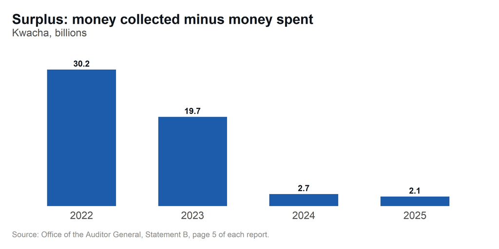

*(The 2021 report does not include this budget table, so 2021 is left out of this section.)*

# What the auditors flagged, and how much

When the auditors cannot fully account for money, they record it under a category, such as money not collected, irregular payments, or funds not properly supported by documents. The 2022 and 2023 reports add these up in a trend table that covers three financial years, 2021, 2022 and 2023. The 2024 and 2025 reports print no total, so no later year can be compared.

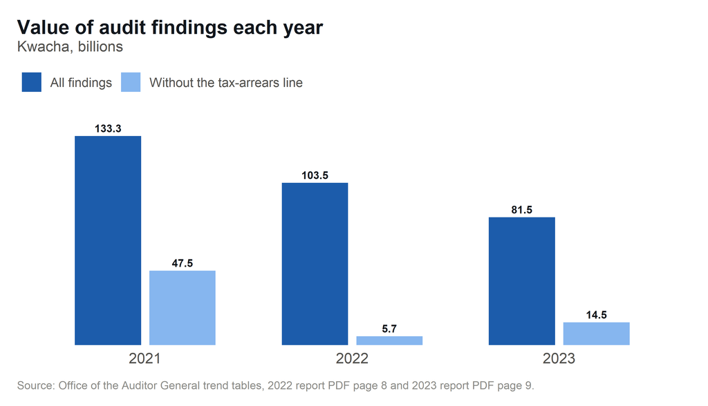

One line dwarfs the rest: **unpaid tax arrears**, which the tax authority (ZRA) reports separately and which runs into tens of billions of Kwacha. It is a running backlog of taxes owed, not money that went missing in the year. Set it aside (the lighter bars) and the rest of the findings are far smaller, and do not simply fall every year.

# Real examples: what was not collected, not delivered, or not supported

Specific cases the reports single out. Amounts are exactly as the reports state them. Kwacha (K) and US dollar (US$) items are kept separate.

**Money the government was owed but did not collect:**

| Year | Ministry | What the report records | Amount | Page |
| --- | --- | --- | --- | --- |
| 2025 | Mines and Minerals Development | Failure to collect penalty fees for breach of licence conditions | K626.6m | p9 |
| 2025 | Finance and National Planning | Imports assessed but not paid for | K42.0m | p7 |
| 2025 | Mines and Minerals Development | Failure to collect outstanding area charges | K30.5m | p8 |
| 2025 | Finance and National Planning | Unsupported extension of temporary import permits | K9.0m | p7 |
| 2025 | Agriculture | Failure to collect seed royalties (balance) | K3.5m | p8 |
| 2025 | Lands and Natural Resources | Failure to bill ground rent due to incomplete land details | K3.3m | p8 |
| 2025 | Home Affairs and Internal Security | Failure to remit immigration fees collected by Access Bank | US$433,820 | p8 |
| 2025 | Home Affairs and Internal Security | Failure to facilitate exit of prohibited immigrants | K408,000 | p8 |
| 2024 | Finance and National Planning | Filed returns without payments | K4.40bn | p8 |
| 2024 | Lands and Natural Resources | Outstanding ground rent | K1.32bn | p8 |
| 2024 | Lands and Natural Resources | Outstanding revenue arrears | K177.9m | p9 |
| 2024 | Finance and National Planning | Failure to monitor transits - potential loss of revenue | K10.9m | p8 |
| 2021 | Finance and National Planning | Failure to reconcile and collect tax arrears | K85.78bn | p8 |
| 2021 | Finance and National Planning | Irregular refund of VAT | K3.56bn | p9 |
| 2021 | Finance and National Planning | Fourteen companies with declared VDP did not pay taxes due | K1.24bn | p8 |
| 2021 | Finance and National Planning | Declaration of nil return for mineral royalty tax | K140.6m | p9 |
| 2021 | Finance and National Planning | Removals in Transit bond guarantees not redeemed | K95.3m | p8 |
| 2021 | Lands and Natural Resources | Failure to collect revenue on outstanding bills | K64.6m | p9 |
| 2021 | Mines and Minerals Development | Failure to collect annual area charges | K32.3m | p9 |
| 2021 | Finance and National Planning | Tax Online System modules not utilised | US$3.6m | p9 |
| 2021 | Home Affairs and Internal Security | Misappropriation of revenues | K3.1m | p10 |
| 2021 | Tourism | Failure to collect hunting and concession fees | K437,888 | p9 |

**Money spent, at risk, or not delivered:**

| Year | Ministry | What the report records | Amount | Page |
| --- | --- | --- | --- | --- |
| 2025 | Health | Failure to settle outstanding obligations | K3.56bn | p9 |
| 2025 | Provincial offices | FISP beneficiaries also on other empowerment programmes | K34.9m | p11 |
| 2025 | Provincial offices | Unapproved farmers on e-voucher redeemed inputs | K19.6m | p11 |
| 2025 | Provincial offices | Inactive farmers loaded with redeemable inputs | K17.8m | p11 |
| 2025 | Community Development and Social Services | Irregular inclusion of FISP beneficiaries into FSP | K3.1m | p9 |
| 2025 | Education | Unaccounted for officers drawing salaries | K1.2m | p10 |
| 2025 | Health | Failure to establish oxygen plant - procurement and transport cost | K853,291 | p9 |
| 2025 | Fisheries and Livestock | Consultant paid in full but M and E system not delivered | K330,000 | p10 |
| 2025 | Health | Expired renal fluids not disposed of | US$11,500 | p9 |
| 2024 | Agriculture | Insurers failed to compensate farmers for poor germination and yield | K113.1m | p10 |
| 2024 | Fisheries and Livestock | Failure to utilise funds (returned to Treasury) | K30.7m | p10 |
| 2024 | Community Development and Social Services | Undelivered farming inputs | K25.7m | p9 |
| 2024 | Education | Questionable facilitation of service provider (APCBL) | K25.7m | p11 |
| 2024 | Health | Questionable inclusion of works already done by previous contractors | K24.0m | p11 |
| 2024 | Water Development and Sanitation | Failure to recover funds on terminated contracts | K20.6m | p10 |
| 2024 | Agriculture | SAFF - failure to recover loans (outstanding balance) | K13.0m | p9 |
| 2024 | Water Development and Sanitation | Failure to recover advance payments on terminated contracts | K12.1m | p10 |
| 2024 | Finance and National Planning | Loss of funds - failure to adhere to assignment agreement (Nyiombo) | US$3.7m | p9 |
| 2024 | Transport and Logistics | Walvis Bay Port concession - unsettled port charges paid by Government | US$1.5m | p12 |
| 2021 | Local Government and Rural Development | Over commitment on feeder roads | K9.43bn | p10 |
| 2021 | Health | Procurement documents not availed for audit | K1.44bn | p14 |
| 2021 | Infrastructure Housing and Urban Development | Over commitment on contract procurement in new districts | K1.38bn | p10 |
| 2021 | Agriculture | Continued procurement through direct bidding (single source) | US$430.3m | p15 |
| 2021 | Health | Seven infectious disease isolation hospitals - unsolicited proposal (TFM) | US$98.8m | p13 |
| 2021 | Health | King Salman Hospital - loan agreement shortfall | US$98.5m | p13 |
| 2021 | Finance and National Planning | Cancellation of concession agreement - Mpulungu Harbour - loss of public funds | US$59.7m | p12 |
| 2021 | Infrastructure Housing and Urban Development | Purchase of office block - seller accrued interest claim | US$25.0m | p10 |
| 2021 | Finance and National Planning | KCM loan facility - failure to collect interest | K23.3m | p12 |
| 2021 | Defence | Supply of Smoke Denisons - cover bidding | K21.1m | p11 |
| 2021 | Health | Uncompetitive procurement of 10000 oxygen cylinders | US$13.0m | p13 |
| 2021 | Defence | Procurement of Sukhoi business jet - undelivered | US$7.8m | p11 |
| 2021 | Defence | Procurement of equipment - failure to deliver | K3.9m | p11 |
| 2021 | Finance and National Planning | Irregular procurement of Zambia Chancery in Turkey | US$2.9m | p12 |
| 2021 | Agriculture | Overpayment of suppliers of farming inputs | K2.6m | p15 |
| 2021 | Defence | Questionable selling price of exported Mukula to China | US$2.5m | p12 |
| 2021 | Works and Supply | Purchase of office building above valuation | US$2.5m | p15 |
| 2021 | Finance and National Planning | Failure to demand arbitration award from Lodestar International | US$2.0m | p13 |
| 2021 | Agriculture | Beneficiaries using the same National Registration Cards | K2.0m | p16 |
| 2021 | Community Development and Social Services | FISP beneficiaries also issued inputs under FSP | K1.2m | p16 |
| 2021 | Mines and Minerals Development | Expired anti-lead poisoning drugs - wasteful expenditure | US$1.0m | p15 |

# Contracts the auditors questioned

This is a first set of named contracts the reports flag, with who got the contract, its value, whether it was delivered, and what the auditors questioned. It is drawn from the reports’ highlighted cases; the full bodies name many more, which is the next piece of work.

| Year | Ministry | Supplier | Contract | Value | Delivered | Auditors flagged | Page |
| --- | --- | --- | --- | --- | --- | --- | --- |
| 2025 | Fisheries and Livestock | Moses Kabwe Mwale | Consultancy for monitoring and evaluation system (Zambia Beef Export Project) | K330,000 | No | undelivered | p10 |
| 2025 | Health | Augusta Limited | Framework contract for renal dialysis consumables (CAPD fluids) | K496.2m | Partial | partial delivery; short-dated drugs; repeated extensions | p109 |
| 2025 | Health | Jiangsu Gold Civil Construction Company Limited | Equipment for Cancer Treatment Centre in Livingstone | K422.3m | No | delayed commencement of works | p114 |
| 2025 | Education | Pozzolana Engineers and Builders Limited | Construction of Kanona Primary ECE Hub (Serenje) | K3.9m | No | contractor abandoned site in 2024; extended 4 times | p154 |
| 2025 | Information and Media | Joshisa Electronics and General Dealers | Supply of 109 laptops | K3.2m | Partial | supplier premises could not be located; delays; re-awarded | p90 |
| 2025 | Health | NMS Infrastructure Limited | Turnkey design construct and equip 5 district hospitals and 120 health centres | US$427.2m | No | contractor not mobilised 9 months after advance; questionable budgeting | p116 |
| 2025 | Health | Zhong Ding International Engineering (JV Wah Kong Enterprises) | King Salman 800-bed Specialist Hospital Lusaka | US$146.5m | Partial | questionable upgrading and replacement of medical equipment | p117 |
| 2024 | Transport and Logistics | African Union Financial Services (Pvt) Ltd | Walvis Bay Port 25-year concession | not stated | not stated | unsettled charges | p12 |
| 2024 | Finance and National Planning | Nyiombo Investments | Fertilizer procurement contract (2016); rights assignment loss | US$30.6m | not stated | loss of funds | p9 |
| 2024 | Education | Alliance Procurement and Capacity Building Limited (APCBL) | Consulting services to public schools colleges and universities | K25.7m | Partial | single-source; unsupported payments | p11 |
| 2024 | Health | Primetime Freight and Customs Brokers | Customs and clearing services for pharmaceuticals and medical goods | not stated | not stated | verbal extension; unsupported payment | p11 |
| 2024 | Water Development and Sanitation | Four contractors (not named) | Four terminated contracts | K48.4m | No | unrecovered advance payment | p10 |
| 2024 | Water Development and Sanitation | Twelve contractors (not named) | Twelve terminated contracts | not stated | No | funds not recovered | p10 |
| 2024 | Health | Three contractors (not named) | Three contracts including works already completed | not stated | not stated | duplicate works | p11 |
| 2024 | Health | Institute for Health Measurement Southern Africa (IHMSA) | SmartCare Pro rollout to 600 health facilities 2024-2027 via Smart Zambia Institute | K360.0m | Partial | delayed; offline capability not developed | p53 |
| 2024 | Health | AVIC International Limited | Construction of Cancer Treatment Centre in Ndola | K306.0m | Partial | delayed; questionable counterpart funding request | p154 |
| 2024 | Health | Siemens Healthineers | Cancer Diseases Hospital Lusaka equipment (turnkey) | US$30.8m | Partial | irregular advance payment without guarantee verification | p151 |
| 2024 | Community Development and Social Services | Buywell Farmers Centre | Maize seed and Impwa supply - Food Security Pack 2024/2025 | K26.8m | Partial | uncertified seed (K9.87m); possibly forged seed analysis report | p140 |
| 2024 | Transport and Logistics | Menov Trading Limited | Supply of pontoon rehabilitation materials | K1.9m | not stated | irregular payment before contract signing | p220 |
| 2023 | Home Affairs and Internal Security | ZTE Zambia Service Limited | Safe City Project - public security network Phase III | US$210.0m | not stated | US$178.5m loan outstanding; unspent funds not remitted | p68 |
| 2022 | Agriculture | 17 seed suppliers (FISP) | Procurement of 33283 MT of seed for the 2022/2023 season | K1.94bn | No | paid before delivery; delivered late | p215 |
| 2022 | Local Government and Rural Development | 238 feeder-road contractors | Periodic maintenance of feeder roads (238 contracts 9317.85 km) | K12.73bn | Partial | over-commitment; delays; 197 contracts terminated | p65 |
| 2022 | Local Government and Rural Development | Henina Engineering and Construction Limited | Construction of modern bus stop in Mpika | K16.8m | No | stalled; contractor off site at 40% | p65 |
| 2021 | Defence | Joint Stock Company | Procurement of one Sukhoi business jet | US$49.4m | No | undelivered | p11 |
| 2021 | Health | Accute Investments Limited | Procurement of 10000 oxygen cylinders | US$13.0m | not stated | uncompetitive; price not established | p13 |
| 2021 | Health | Contractor (not named) | Construction of King Salman Bin Abdulaziz Specialist Hospital | US$146.5m | not stated | funding shortfall | p13 |
| 2021 | Health | TFM | Construction and equipping of seven 150-bed infectious disease isolation hospitals | US$98.8m | not stated | no past experience; price not established | p13 |
| 2021 | Infrastructure Housing and Urban Development | Zamworth Construction Limited | Purchase of Ministry office block | US$5.3m | Partial | delayed payment; interest claim | p10 |
| 2021 | Defence | Apex Supplies | Supply of Smoke Denisons | K21.1m | not stated | cover bidding | p11 |
| 2021 | Finance and National Planning | Developer (not named) | Development of the Tax Online System (ZRA) | US$3.6m | Yes | system not utilised | p9 |
| 2021 | Finance and National Planning | Vendor (not named) | Purchase of Zambia Chancery in Turkey | US$6.9m | not stated | unsupported fees | p12 |
| 2021 | Works and Supply | Seller (former German Embassy) | Purchase of office building above valuation | US$2.5m | Yes | overpriced | p15 |
| 2021 | Agriculture | Various suppliers | Procurement of farming inputs through direct bidding | US$430.3m | Partial | single-source; partial delivery | p15 |
| 2021 | Defence | ZNS Shandong (ZNSSACCO) | Export of Mukula logs to China | not stated | Yes | under-declaration | p12 |

Read these the same way as the rest: a flagged contract is a question the auditors raised, not a proven loss. “Delivered: No” means the records did not show delivery when the report was written.

# Which ministries come up most often

The reports are organised by ministry. Counting how often each appears with an unresolved question shows who recurs, even where no single total is given.

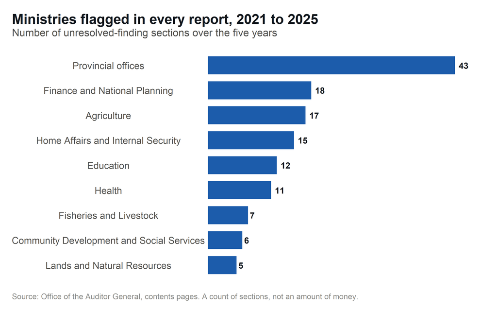

Nine portfolios appear in **every** report over the five years. Provincial offices under the Office of the President come up most, then Finance, Agriculture, Home Affairs, Education, and Health. This shows where problems recur, not which ministry lost the most money.

# How to read these numbers fairly

- **A finding is a question, not a verdict.** Say “the report records K3.56 billion in unpaid obligations,” not “the ministry lost K3.56 billion.”
- **Not every year lines up.** The budget table is missing for 2021; comparable findings totals exist only for 2021 to 2023, printed in the 2022 and 2023 reports; the 2024 and 2025 reports list examples instead of one total.
- **One huge line (tax arrears) distorts the totals**, so it is shown separately.
- **US dollar and Kwacha amounts are never added together.**
- **The contracts list is a first set**, drawn from highlighted cases, not every contract in the reports.
- These figures come from the published main reports only. Ministries may have since given explanations, recorded in later reports and parliamentary committees.

# Where this comes from

Five reports from the Office of the Auditor General of Zambia, *Reports on the Accounts of the Republic*, for the years ended 31 December 2021 to 2025. Cite any figure with the report year and the page shown here, for example *Auditor General, 2025 report, page 5.*

The full data, the page reference for every number, and the code behind each chart are in the project repository: **https://github.com/Chanza-bj/AG_Report_Analysis**